# Assignment 2: Spatial Analysis and Visualization

Healthcare Access and Equity in Pennsylvania

Author

Your Name Here

Published

November 19, 2025

## Part 1: Healthcare Access for Vulnerable Populations

**Your Task:**

```r
# Load required packages
library(sf)
library(dplyr)
library(tigris)
options(tigris_use_cache = TRUE, tigris_class = "sf")
library(tidycensus)
library(knitr)
library(ggplot2)
library(scales)

# Load spatial data
# counties: shapefile in data/
pa_counties <- st_read("data/Pennsylvania_County_Boundaries.shp", quiet = TRUE)
# hospitals: GeoJSON in data/
hospitals <- st_read("data/hospitals.geojson", quiet = TRUE)
# census tracts: from tigris
census_tracts <- tracts(state = "PA", cb = TRUE, year = 2023)

# Make CRS consistent with counties
hospitals     <- st_transform(hospitals,     st_crs(pa_counties))
census_tracts <- st_transform(census_tracts, st_crs(pa_counties))

# Check that all data loaded correctly
list(
  rows_counties   = nrow(pa_counties),
  rows_hospitals  = nrow(hospitals),
  rows_tracts     = nrow(census_tracts),
  crs_counties    = st_crs(pa_counties)$input,
  crs_hospitals   = st_crs(hospitals)$input,
  crs_tracts      = st_crs(census_tracts)$input,
  geom_counties   = unique(st_geometry_type(pa_counties)),
  geom_hospitals  = unique(st_geometry_type(hospitals)),
  geom_tracts     = unique(st_geometry_type(census_tracts))
)
```

```
$rows_counties
[1] 67

$rows_hospitals
[1] 223

$rows_tracts
[1] 3445

$crs_counties
[1] "WGS 84 / Pseudo-Mercator"

$crs_hospitals
[1] "WGS 84 / Pseudo-Mercator"

$crs_tracts
[1] "WGS 84 / Pseudo-Mercator"

$geom_counties
[1] MULTIPOLYGON
18 Levels: GEOMETRY POINT LINESTRING POLYGON MULTIPOINT ... TRIANGLE

$geom_hospitals
[1] POINT
18 Levels: GEOMETRY POINT LINESTRING POLYGON MULTIPOINT ... TRIANGLE

$geom_tracts
[1] MULTIPOLYGON
18 Levels: GEOMETRY POINT LINESTRING POLYGON MULTIPOINT ... TRIANGLE
```

There are 223 hospitals in Pennsylvania according to the provided dataset. There are 3,445 census tracts across the state. All three layers (counties, hospitals, tracts) are currently in WGS 84 / Pseudo-Mercator (EPSG:3857). —

#### Step 2: Get Demographic Data

```r
# Get demographic data from ACS
# 1) Set ACS year
acs_year <- 2022   # most recent 5-year estimates

# 2) Variables:
# B01003_001 = total population
# B19013_001 = median household income
# B01001_020 + B01001_021 + B01001_044 + B01001_045 = age 65+ (male + female groups)
vars <- c(
  total_pop = "B01003_001",
  median_income = "B19013_001",
  male65_66   = "B01001_020",
  male67_69   = "B01001_021",
  male70_74   = "B01001_022",
  male75_79   = "B01001_023",
  male80_84   = "B01001_024",
  male85plus  = "B01001_025",
  female65_66 = "B01001_044",
  female67_69 = "B01001_045",
  female70_74 = "B01001_046",
  female75_79 = "B01001_047",
  female80_84 = "B01001_048",
  female85plus= "B01001_049"
)

# 3) Pull ACS data at tract level for PA
pa_demo <- get_acs(
  geography = "tract",
  state = "PA",
  variables = vars,
  year = acs_year,
  survey = "acs5",
  output = "wide"
)

# 4) Compute elderly population (sum male+female 65+)
pa_demo <- pa_demo %>%
  mutate(
    over65 = male65_66E + male67_69E + male70_74E + male75_79E +
             male80_84E + male85plusE +
             female65_66E + female67_69E + female70_74E +
             female75_79E + female80_84E + female85plusE
  ) %>%
  select(GEOID, total_popE, median_incomeE, over65)

# 5) Join to tract boundaries
census_tracts_demo <- census_tracts %>%
  left_join(pa_demo, by = "GEOID")

# How many tracts missing income?
missing_income <- sum(is.na(census_tracts_demo$median_incomeE))
# Median income across all tracts (ignoring missing)
overall_median_income <- median(census_tracts_demo$median_incomeE, na.rm = TRUE)
list(
  acs_year_used = acs_year,
  n_tracts = nrow(census_tracts_demo),
  missing_income_tracts = missing_income,
  median_income_all_tracts = overall_median_income
)
```

```
$acs_year_used
[1] 2022

$n_tracts
[1] 3445

$missing_income_tracts
[1] 62

$median_income_all_tracts
[1] 70188
```

ACS year used: 2022 (5-year estimates) Number of census tracts in dataset: 3,445 Tracts with missing income data: 62 Median household income across all PA tracts: $70,188 —

#### Step 3: Define Vulnerable Populations

```r
# Filter for vulnerable tracts based on your criteria
# 1) Define thresholds
income_threshold <- 50000 # $50,000 income
elderly_pct_threshold <- 0.17 # 17% elderly

# 2) Compute elderly percentage
census_tracts_demo <- census_tracts_demo %>%
  mutate(
    pct_over65 = over65 / total_popE,
    vulnerable = if_else(median_incomeE < income_threshold & pct_over65 > elderly_pct_threshold, 1, 0)
  )

# 3) Summary counts
n_vulnerable <- sum(census_tracts_demo$vulnerable, na.rm = TRUE)
n_total <- nrow(census_tracts_demo)
pct_vulnerable <- round(100 * n_vulnerable / n_total, 1)

list(
  income_threshold = income_threshold,
  elderly_threshold = elderly_pct_threshold,
  vulnerable_tracts = n_vulnerable,
  pct_vulnerable = pct_vulnerable
)
```

```
$income_threshold
[1] 50000

$elderly_threshold
[1] 0.17

$vulnerable_tracts
[1] 253

$pct_vulnerable
[1] 7.3
```

#### Step 4: Calculate Distance to Hospitals

```r
# Transform to appropriate projected CRS
census_tracts_proj <- st_transform(census_tracts_demo, 5070)
hospitals_proj <- st_transform(hospitals, 5070)

# Calculate distance from each tract centroid to nearest hospital
tract_centroids <- st_centroid(census_tracts_proj)
dist_matrix <- st_distance(tract_centroids, hospitals_proj)
tract_centroids$nearest_hosp_dist_m <- apply(dist_matrix, 1, min)
tract_centroids$nearest_hosp_dist_mi <- tract_centroids$nearest_hosp_dist_m / 1609.34

vulnerable_tracts_dist <- tract_centroids %>%
  filter(vulnerable == 1) %>%
  st_drop_geometry() %>%
  select(GEOID, median_incomeE, pct_over65, nearest_hosp_dist_mi)

summary_stats <- summary(vulnerable_tracts_dist$nearest_hosp_dist_mi)
summary_stats
```

```
    Min.  1st Qu.   Median     Mean  3rd Qu.     Max.
 0.02107  0.83908  1.80602  3.27466  3.55821 18.64304
```

This projection uses meters as its unit, which avoids distortions from geographic CRS like WGS84 (degrees), so distances can be directly converted to miles.

#### Step 5: Identify Underserved Areas

```r
# Create underserved variable
tract_centroids <- tract_centroids %>%
  mutate(
    underserved = if_else(vulnerable == 1 & nearest_hosp_dist_mi > 15, 1, 0)
  )

n_underserved <- sum(tract_centroids$underserved, na.rm = TRUE)
n_vulnerable <- sum(tract_centroids$vulnerable, na.rm = TRUE)
pct_underserved <- round(100 * n_underserved / n_vulnerable, 1)

list(
  underserved_tracts = n_underserved,
  vulnerable_tracts_total = n_vulnerable,
  pct_vulnerable_underserved = pct_underserved
)
```

```
$underserved_tracts
[1] 7

$vulnerable_tracts_total
[1] 253

$pct_vulnerable_underserved
[1] 2.8
```

7 tracts meet the definition. 2.8% of vulnerable tracts are undeserved.This result is not very surprising. Most of Pennsylvania’s population—and thus its healthcare infrastructure—is concentrated in urban and suburban counties. Rural areas may have some underserved tracts, but they are relatively few in number.

#### Step 6: Aggregate to County Level

```r
# Spatial join tracts to counties
pa_counties_proj <- st_transform(pa_counties, 5070)
tract_centroids_proj <- st_transform(tract_centroids, 5070)
tracts_with_county <- st_join(tract_centroids_proj, pa_counties_proj, join = st_within)

# Aggregate statistics by county
county_stats <- tracts_with_county %>%
  st_drop_geometry() %>%
  group_by(COUNTY_NAM) %>%
  summarize(
    vulnerable_tracts = sum(vulnerable, na.rm = TRUE),
    underserved_tracts = sum(underserved, na.rm = TRUE),
    pct_underserved = ifelse(vulnerable_tracts > 0,
                             100 * underserved_tracts / vulnerable_tracts, NA),
    avg_distance_vuln_mi = mean(nearest_hosp_dist_mi[vulnerable == 1], na.rm = TRUE),
    vulnerable_population = sum(over65[vulnerable == 1], na.rm = TRUE) # 65+ as proxy for vulnerable pop
  ) %>%
  arrange(desc(pct_underserved))

head(county_stats, 10)
```

```
# A tibble: 10 × 6
   COUNTY_NAM vulnerable_tracts underserved_tracts pct_underserved
   <chr>                  <dbl>              <dbl>           <dbl>
 1 CAMERON                    1                  1           100
 2 FOREST                     2                  2           100
 3 MONROE                     1                  1           100
 4 CLEARFIELD                 3                  2            66.7
 5 JUNIATA                    2                  1            50
 6 ADAMS                      1                  0             0
 7 ALLEGHENY                 49                  0             0
 8 ARMSTRONG                  1                  0             0
 9 BEAVER                     8                  0             0
10 BEDFORD                    2                  0             0
# ℹ 2 more variables: avg_distance_vuln_mi <dbl>, vulnerable_population <dbl>
```

Cameron (100%) – 1 vulnerable tract, and it is underserved. Forest (100%) – 2 vulnerable tracts, both underserved. Monroe (100%) – 1 vulnerable tract, underserved. Clearfield (66.7%) – 3 vulnerable tracts, 2 underserved. Juniata (50%) – 2 vulnerable tracts, 1 underserved. From the current table, counties like Cameron, Forest, and Clearfield stand out, because although they don’t have many tracts, nearly all of their vulnerable tracts are underserved and the average distance to the nearest hospital is 15–19 miles. Yes. The underserved counties are concentrated in rural and sparsely populated areas (Northern and Central Pennsylvania: Cameron, Forest, Clearfield, Juniata). These counties have few hospitals and residents often face long travel times. —

#### Step 7: Create Summary Table

```r
# Create and format priority counties table
priority_counties <- county_stats %>%
  mutate(
    `% Underserved` = round(pct_underserved, 1),
    `Avg Distance (mi)` = round(avg_distance_vuln_mi, 1),
    `Vulnerable Pop (65+)` = comma(vulnerable_population)
  ) %>%
  arrange(desc(`% Underserved`), desc(as.numeric(gsub(",", "", `Vulnerable Pop (65+)`)))) %>%
  slice(1:10) %>%
  select(
    County = COUNTY_NAM,
    `Vulnerable Tracts` = vulnerable_tracts,
    `Underserved Tracts` = underserved_tracts,
    `% Underserved`,
    `Avg Distance (mi)`,
    `Vulnerable Pop (65+)`
  )

kable(
  priority_counties,
  caption = "Top 10 Pennsylvania Counties with Highest Priority for Healthcare Investment (based on underserved vulnerable tracts and population needs)",
  align = "lccccc",
  format = "markdown"
)
```

Top 10 Pennsylvania Counties with Highest Priority for Healthcare Investment (based on underserved vulnerable tracts and population needs)

| County | Vulnerable Tracts | Underserved Tracts | % Underserved | Avg Distance (mi) | Vulnerable Pop (65+) |
| --- | --- | --- | --- | --- | --- |
| FOREST | 2 | 2 | 100.0 | 18.3 | 1,593 |
| CAMERON | 1 | 1 | 100.0 | 18.6 | 428 |
| MONROE | 1 | 1 | 100.0 | 17.6 | 314 |
| CLEARFIELD | 3 | 2 | 66.7 | 15.5 | 2,083 |
| JUNIATA | 2 | 1 | 50.0 | 12.6 | 1,332 |
| PHILADELPHIA | 38 | 0 | 0.0 | 1.0 | 32,275 |
| ALLEGHENY | 49 | 0 | 0.0 | 2.2 | 27,071 |
| WESTMORELAND | 14 | 0 | 0.0 | 3.2 | 8,023 |
| LUZERNE | 10 | 0 | 0.0 | 3.2 | 7,619 |
| FAYETTE | 9 | 0 | 0.0 | 3.6 | 7,158 |

## Part 2: Comprehensive Visualization

### Map 1: County-Level Choropleth

**Your Task:**

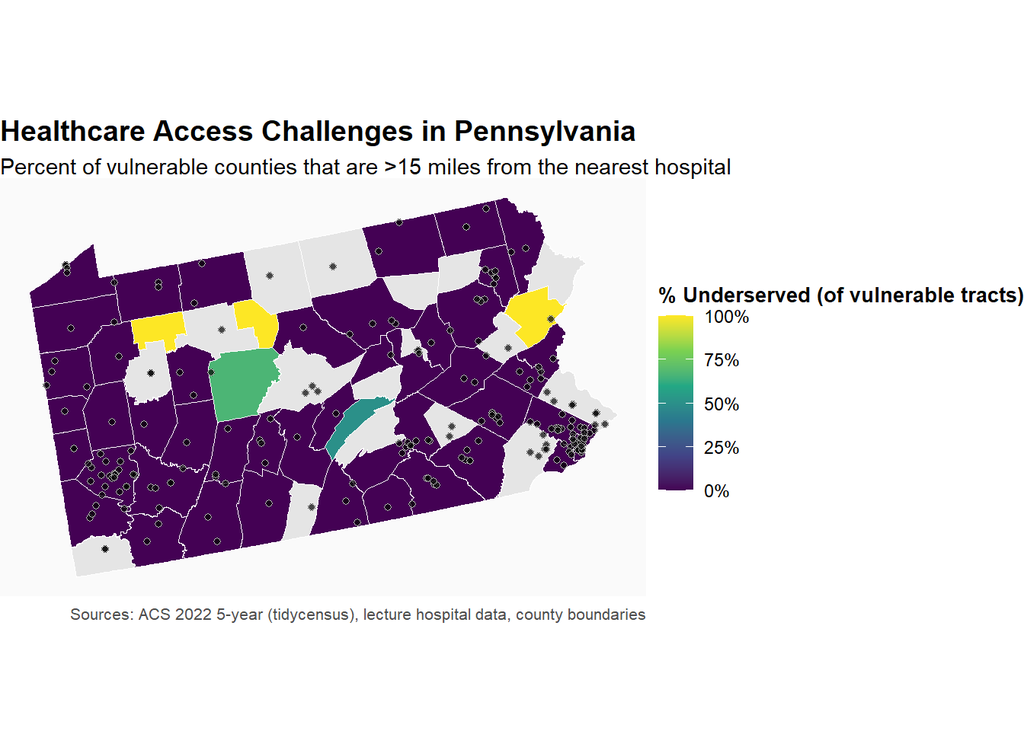

```r
# Create detailed tract-level map
library(dplyr)
library(ggplot2)
library(sf)
library(scales)

pa_counties_map <- pa_counties_proj %>%
  left_join(
    county_stats %>%
      mutate(pct_underserved = as.numeric(pct_underserved)),
    by = c("COUNTY_NAM")
  )

ggplot() +
  geom_sf(
    data = pa_counties_map,
    aes(fill = pct_underserved),
    color = "white", size = 0.25
  ) +
  geom_sf(
    data = hospitals_proj,
    shape = 21, fill = "black", color = "white", size = 1.4, alpha = 0.7
  ) +
  scale_fill_viridis_c(
    name = "% Underserved (of vulnerable tracts)",
    labels = function(x) paste0(x, "%"),
    na.value = "grey90",
    option = "-magma",
    limits = c(0, 100)
  ) +
  labs(
    title = "Healthcare Access Challenges in Pennsylvania",
    subtitle = "Percent of vulnerable counties that are >15 miles from the nearest hospital",
    caption = "Sources: ACS 2022 5-year (tidycensus), lecture hospital data, county boundaries"
  ) +
  theme_void() +
  theme(
    legend.position = "right",
    legend.title = element_text(size = 10, face = "bold"),
    legend.text  = element_text(size = 9),
    plot.title   = element_text(size = 14, face = "bold"),
    plot.subtitle= element_text(size = 11),
    plot.caption = element_text(size = 8, color = "grey30"),
    panel.background = element_rect(fill = "grey98", color = NA)
  )
```

**Requirements:** - Fill counties by percentage of vulnerable tracts that are underserved - Include hospital locations as points - Use an appropriate color scheme - Include clear title, subtitle, and caption - Use `theme_void()` or similar clean theme - Add a legend with formatted labels

### Map 2: Detailed Vulnerability Map

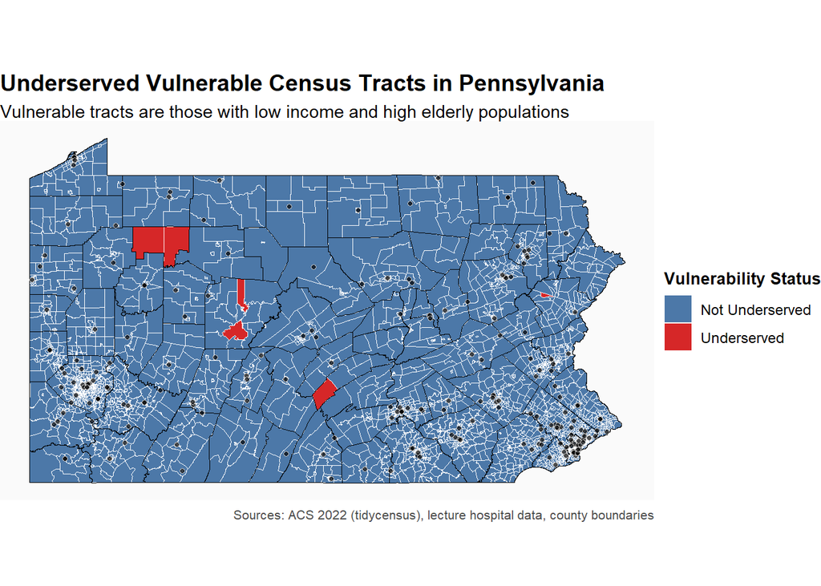

```r
tracts_final <- census_tracts_demo %>%
  left_join(
    tract_centroids %>%
      st_drop_geometry() %>%
      select(GEOID, nearest_hosp_dist_mi, vulnerable, underserved),
    by = "GEOID"
  )

ggplot() +
  geom_sf(
    data = tracts_final,
    aes(fill = factor(underserved, levels = c(0, 1), labels = c("Not Underserved", "Underserved"))),
    color = "white", size = 0.1
  ) +
  geom_sf(
    data = pa_counties_proj,
    fill = NA, color = "black", size = 0.3
  ) +
  geom_sf(
    data = hospitals_proj,
    shape = 21, fill = "black", color = "white", size = 1.2, alpha = 0.7
  ) +
  scale_fill_manual(
    name = "Vulnerability Status",
    values = c("Not Underserved" = "#4C78A8", "Underserved" = "#D62728"),
    na.value = "grey90"
  ) +
  labs(
    title = "Underserved Vulnerable Census Tracts in Pennsylvania",
    subtitle = "Vulnerable tracts are those with low income and high elderly populations",
    caption = "Sources: ACS 2022 (tidycensus), lecture hospital data, county boundaries"
  ) +
  theme_void() +
  theme(
    legend.position = "right",
    legend.title = element_text(size = 10, face = "bold"),
    legend.text  = element_text(size = 9),
    plot.title   = element_text(size = 14, face = "bold"),
    plot.subtitle= element_text(size = 11),
    plot.caption = element_text(size = 8, color = "grey30"),
    panel.background = element_rect(fill = "grey98", color = NA)
  )
```

### Chart: Distribution Analysis

Create a visualization showing the distribution of distances to hospitals for vulnerable populations.

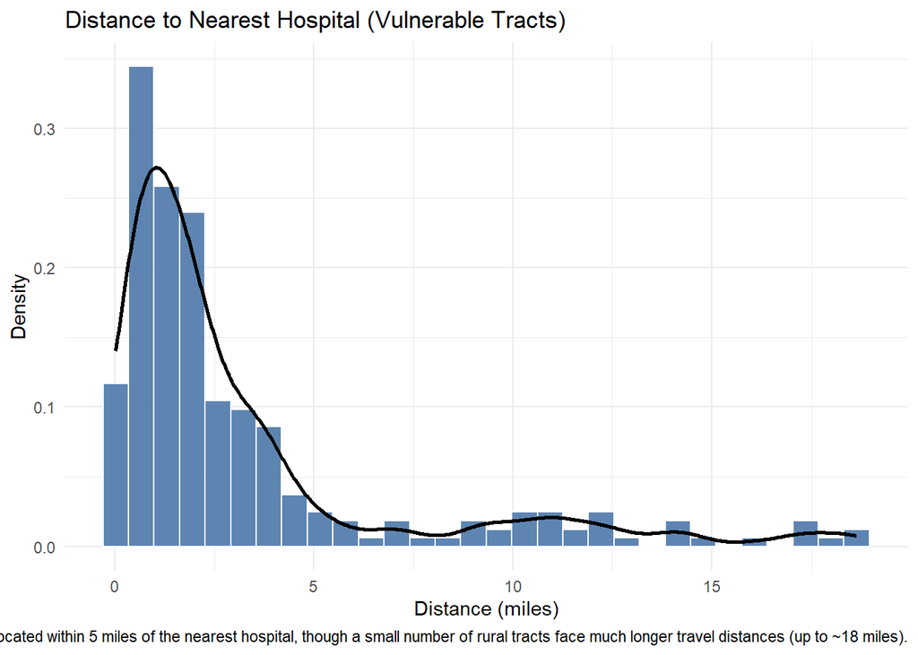

```r
# Create distribution visualization
vuln <- tract_centroids %>%
  st_drop_geometry() %>%
  filter(vulnerable == 1)

ggplot(vuln, aes(x = nearest_hosp_dist_mi)) +
  geom_histogram(aes(y = after_stat(density)), bins = 30, fill = "#4C78A8", color = "white", alpha = 0.9) +
  geom_density(linewidth = 1) +
  labs(
    title = "Distance to Nearest Hospital (Vulnerable Tracts)",
    x = "Distance (miles)",
    y = "Density",
    caption = "Most vulnerable tracts are located within 5 miles of the nearest hospital, though a small number of rural tracts face much longer travel distances (up to ~18 miles)."
  ) +
  theme_minimal(base_size = 11)
```